# Assignment 3 - Our own data analysis

Akaran Sivakumar (AS), Lelia Rønnow (LR), Shiraz Ben-Shoshan (SBS)

01-12-2024

# Setup

## Loading packages and data

```r
library(tidyverse)
#install.packages("countrycode")
library(countrycode)
```

```r
# Setting working directory
#setwd("~/Desktop/AarhusUni/Semester5/IntroCultDataSci")

# Loading Data
WHO_MHExp_and_Deaths <- read_csv("archive/WHO_MHExp_and_Deaths.csv")
```

# Preliminary data visualisations (AS)

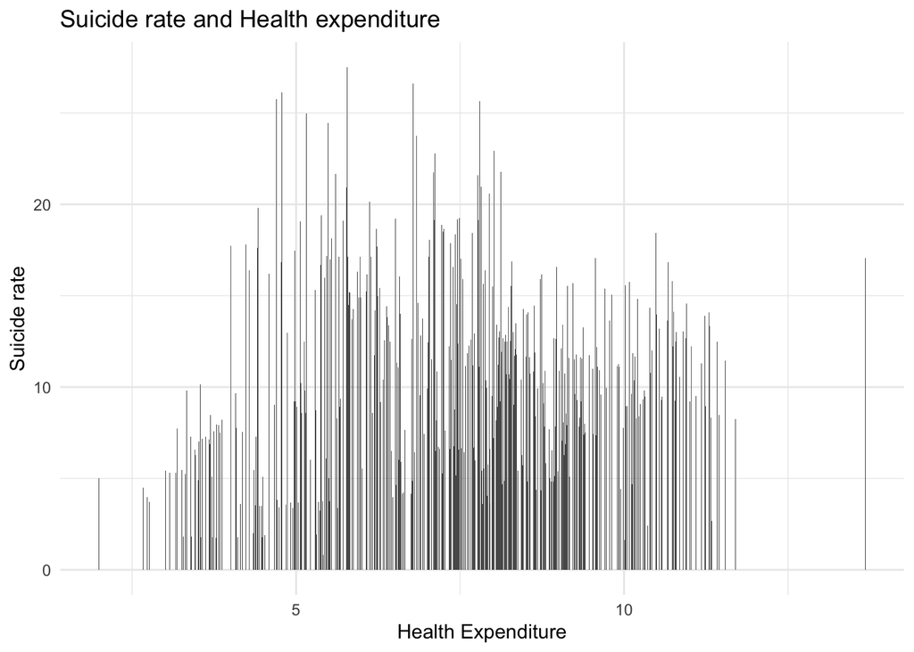

```r
WHO_MHExp_and_Deaths %>%
ggplot(aes(x = HExp_Pctage_Y,
y = Suicide_p100)) +
geom_bar(stat = "summary", fun = "mean") +
theme_minimal() +
labs(x = "Health Expenditure", y = "Suicide rate") +
ggtitle("Suicide rate and Health expenditure")
```

The plot above does not show any clear patterns, so we will now conduct further exploratory plots to discover hidden patterns.

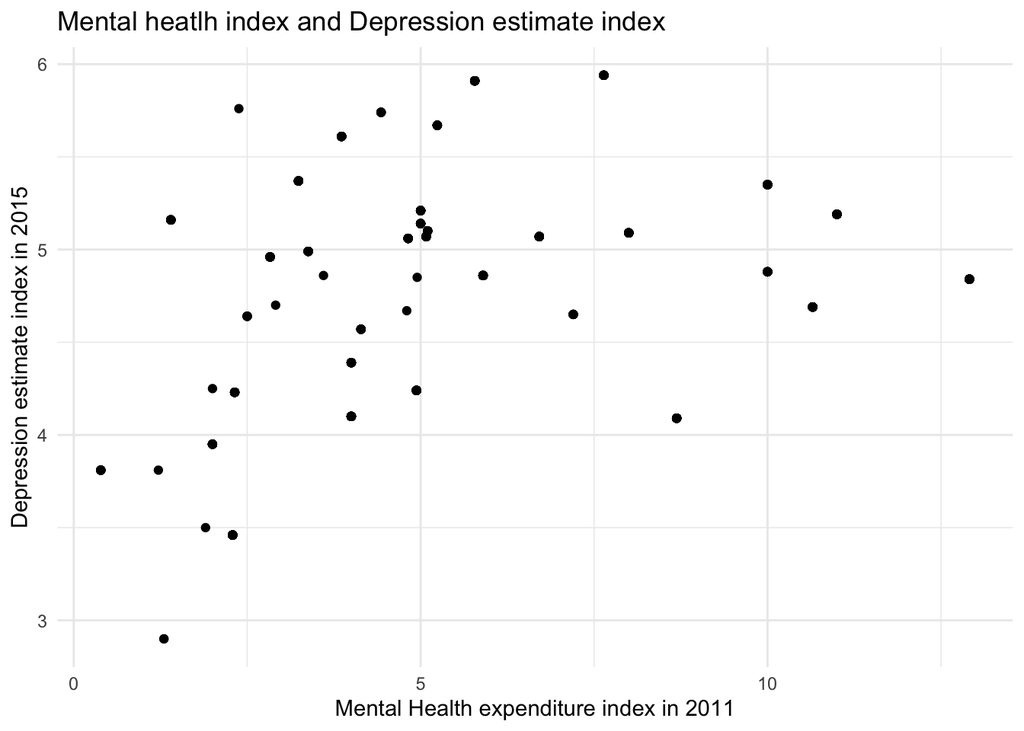

```r
WHO_MHExp_and_Deaths %>%
ggplot(aes(x = MHExp_Pctage_2011,
y = Dep_Num_2015)) +
geom_point()+
theme_minimal() +
labs(x = "Mental Health expenditure index in 2011", y = "Depression estimate index in 2015") +
ggtitle("Mental heatlh index and Depression estimate index")
```

## Data mutation and further visualisations (LR)

```r
# Load the package
library(reshape2)
```

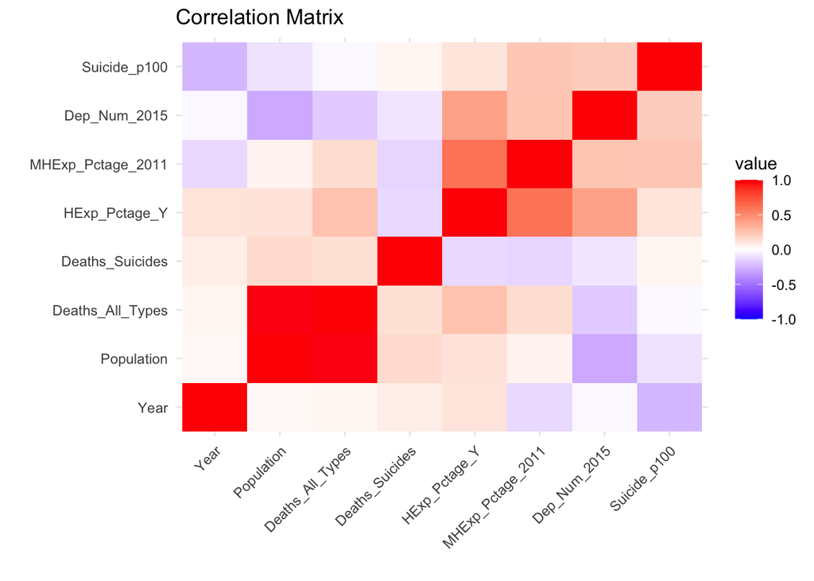

```r
# Converting nominal deaths to a ratio of per 100k
WHO_MHExp_and_Deaths$Deaths_per_100k <- (WHO_MHExp_and_Deaths$Deaths_All_Types / WHO_MHExp_and_Deaths$Population) * 100000

# Convert country names to continent names
WHO_MHExp_and_Deaths$continents <- countrycode(WHO_MHExp_and_Deaths$Country_Name, origin = "country.name", destination = "continent")

# Remove the first and last columns
df_filtered <- WHO_MHExp_and_Deaths[, -c(1, ncol(WHO_MHExp_and_Deaths)-1)]

numeric_df <- df_filtered[, sapply(df_filtered, is.numeric)]
# Calculate the correlation matrix and convert it to a long format
cor_matrix <- cor(numeric_df, use = "complete.obs")
cor_long <- melt(cor_matrix)

# Correlation matrix plot
ggplot(cor_long, aes(x = Var1, y = Var2, fill = value)) +
  geom_tile() +
  scale_fill_gradient2(low = "blue", high = "red", mid = "white", midpoint = 0, limit = c(-1, 1)) +
  theme_minimal() +
  labs(title = "Correlation Matrix", x = "", y = "") +
  theme(axis.text.x = element_text(angle = 45, vjust = 1, hjust = 1))
```

Given the results in the correlation matrix, we see a semi-strong correlation between the mental health expenditure index and the health expenditure percentage. We have, therefore, decided not to include mental health expenditure index in any models, to avoid multicolinearity.

# Modelling (AS)

```r
# Creating the first and most simple model
simple_model <- lm(Suicide_p100 ~ HExp_Pctage_Y, WHO_MHExp_and_Deaths)

summary(simple_model)
```

```
##
## Call:
## lm(formula = Suicide_p100 ~ HExp_Pctage_Y, data = WHO_MHExp_and_Deaths)
##
## Residuals:
##     Min      1Q  Median      3Q     Max
## -9.8939 -4.2753 -0.6807  3.4656 19.4103
##
## Coefficients:
##               Estimate Std. Error t value Pr(>|t|)
## (Intercept)     8.6435     0.8846   9.771   <2e-16 ***
## HExp_Pctage_Y   0.2898     0.1128   2.569   0.0105 *
## ---
## Signif. codes:  0 '***' 0.001 '**' 0.01 '*' 0.05 '.' 0.1 ' ' 1
##
## Residual standard error: 5.463 on 529 degrees of freedom
## Multiple R-squared:  0.01232,    Adjusted R-squared:  0.01045
## F-statistic: 6.599 on 1 and 529 DF,  p-value: 0.01048
```

Health expenditure percentage seems to have an effect on the suicide rate, but there is still a lot of unexplained variance.

## Adding Random Effects (SBS)

```r
#install.packages("lmerTest")
#install.packages("MuMIn")
library(MuMIn)
library(lmerTest)
# Adding country as a random intercept
mixed_model <- lmer(Suicide_p100 ~ HExp_Pctage_Y+(1|Country_Name), WHO_MHExp_and_Deaths)
summary(mixed_model)
```

```
## Linear mixed model fit by REML. t-tests use Satterthwaite's method [
## lmerModLmerTest]
## Formula: Suicide_p100 ~ HExp_Pctage_Y + (1 | Country_Name)
##    Data: WHO_MHExp_and_Deaths
##
## REML criterion at convergence: 2402.2
##
## Scaled residuals:
##     Min      1Q  Median      3Q     Max
## -3.4558 -0.3558 -0.0301  0.3961  4.7487
##
## Random effects:
##  Groups       Name        Variance Std.Dev.
##  Country_Name (Intercept) 28.962   5.382
##  Residual                  3.885   1.971
## Number of obs: 531, groups:  Country_Name, 42
##
## Fixed effects:
##               Estimate Std. Error       df t value Pr(>|t|)
## (Intercept)    12.5161     1.1110 108.2106  11.266  < 2e-16 ***
## HExp_Pctage_Y  -0.3750     0.1012 528.0301  -3.705 0.000234 ***
## ---
## Signif. codes:  0 '***' 0.001 '**' 0.01 '*' 0.05 '.' 0.1 ' ' 1
##
## Correlation of Fixed Effects:
##             (Intr)
## HExp_Pctg_Y -0.650
```

```r
# Calculating the marginal and conditional R-sqaured
r_squared <- r.squaredGLMM(mixed_model)
print(r_squared)
```

```
##             R2m      R2c
## [1,] 0.01859253 0.883929
```

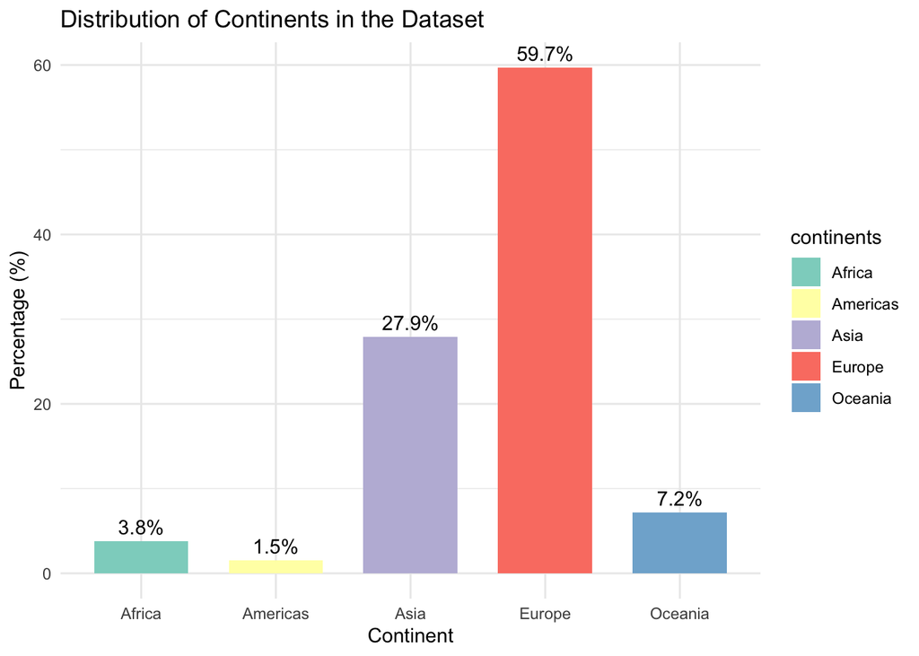

```r
# Adding continent as a column
data <- WHO_MHExp_and_Deaths %>%
  count(continents)

# Counting the occurrences of each continent and calculating the percentage
data <- WHO_MHExp_and_Deaths %>%
  count(continents) %>%
  mutate(percentage = n / sum(n) * 100)

# Creating a bar plot to visualise the imbalance in the data
ggplot(data, aes(x = continents, y = percentage, fill = continents)) +
  geom_bar(stat = "identity", width = 0.7) +
  labs(title = "Distribution of Continents in the Dataset",
       x = "Continent",
       y = "Percentage (%)") +
  scale_fill_brewer(palette = "Set3") +
  geom_text(aes(label = paste0(round(percentage, 1), "%")),
            vjust = -0.5) +
  theme_minimal()
```

The bar plot shows that Europe is very prominent in the data, compared to the other countries, thus telling us that we should take the results with a grain of salt.

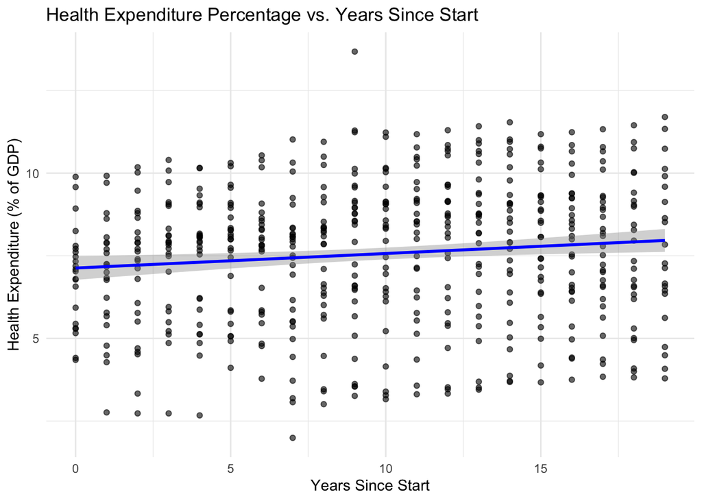

```r
# recalculating the "Year" column to use in models
WHO_MHExp_and_Deaths$Year_since_start <- WHO_MHExp_and_Deaths$Year-2000

# Creating a plot with the Year as a predictor
ggplot(WHO_MHExp_and_Deaths, aes(x = Year_since_start, y = HExp_Pctage_Y)) +
  geom_point(alpha = 0.6) +
  geom_smooth(method = "lm", color = "blue", se = TRUE) +
  labs(
    title = "Health Expenditure Percentage vs. Years Since Start",
    x = "Years Since Start",
    y = "Health Expenditure (% of GDP)"
  ) +
  theme_minimal()
```

Visual inspection shows a slightly positive slope between the year and the health expenditure percentage.

## Adding more Predictors (LR)

```r
# Adding continent as an interaction term
continent_simple_model <- lm(Suicide_p100 ~ HExp_Pctage_Y+HExp_Pctage_Y:continents ,WHO_MHExp_and_Deaths)
summary(continent_simple_model)
```

```
##
## Call:
## lm(formula = Suicide_p100 ~ HExp_Pctage_Y + HExp_Pctage_Y:continents,
##     data = WHO_MHExp_and_Deaths)
##
## Residuals:
##     Min      1Q  Median      3Q     Max
## -8.7478 -3.7308 -0.4028  3.1358 17.7829
##
## Coefficients:
##                                  Estimate Std. Error t value Pr(>|t|)
## (Intercept)                       11.6190     0.9188  12.645  < 2e-16 ***
## HExp_Pctage_Y                     -1.6077     0.2971  -5.411 9.53e-08 ***
## HExp_Pctage_Y:continentsAmericas   1.3934     0.3231   4.313 1.93e-05 ***
## HExp_Pctage_Y:continentsAsia       1.2286     0.2477   4.961 9.49e-07 ***
## HExp_Pctage_Y:continentsEurope     1.6497     0.2479   6.654 7.17e-11 ***
## HExp_Pctage_Y:continentsOceania    1.5840     0.2648   5.981 4.11e-09 ***
## ---
## Signif. codes:  0 '***' 0.001 '**' 0.01 '*' 0.05 '.' 0.1 ' ' 1
##
## Residual standard error: 5.172 on 525 degrees of freedom
## Multiple R-squared:  0.1212, Adjusted R-squared:  0.1128
## F-statistic: 14.48 on 5 and 525 DF,  p-value: 2.672e-13
```

```r
# Calculating the marginal and conditional R-sqaured
r_squared <- r.squaredGLMM(continent_simple_model)
print(r_squared)
```

```
##            R2m       R2c
## [1,] 0.1201577 0.1201577
```

```r
# Adding continent as both an interaction term and as a fixed predictor
continent_model <- lm(Suicide_p100 ~ HExp_Pctage_Y*continents ,WHO_MHExp_and_Deaths)
summary(continent_model)
```

```
##
## Call:
## lm(formula = Suicide_p100 ~ HExp_Pctage_Y * continents, data = WHO_MHExp_and_Deaths)
##
## Residuals:
##     Min      1Q  Median      3Q     Max
## -9.4643 -3.2468  0.1032  2.5011 13.6578
##
## Coefficients:
##                                   Estimate Std. Error t value Pr(>|t|)
## (Intercept)                       3.600356  11.861307   0.304    0.762
## HExp_Pctage_Y                     0.001242   2.389326   0.001    1.000
## continentsAmericas                4.840862  25.063565   0.193    0.847
## continentsAsia                    0.262793  11.911741   0.022    0.982
## continentsEurope                 19.273319  11.936700   1.615    0.107
## continentsOceania                13.071291  12.655417   1.033    0.302
## HExp_Pctage_Y:continentsAmericas  0.147090   3.477538   0.042    0.966
## HExp_Pctage_Y:continentsAsia      0.723151   2.395111   0.302    0.763
## HExp_Pctage_Y:continentsEurope   -1.269896   2.394614  -0.530    0.596
## HExp_Pctage_Y:continentsOceania  -0.619527   2.446758  -0.253    0.800
##
## Residual standard error: 4.672 on 521 degrees of freedom
## Multiple R-squared:  0.2885, Adjusted R-squared:  0.2762
## F-statistic: 23.48 on 9 and 521 DF,  p-value: < 2.2e-16
```

```r
# Calculating the marginal and conditional R-sqaured
r_squared <- r.squaredGLMM(continent_model)
print(r_squared)
```

```
##            R2m       R2c
## [1,] 0.2850245 0.2850245
```

The explainability of both models do not seem as strong as the models with countries as random intercepts.

# Model Selection (SBS)

```r
#using AIC to select the best and simplest model
AIC(simple_model, continent_model,continent_simple_model, mixed_model)
```

```
##                        df      AIC
## simple_model            3 3314.114
## continent_model        11 3155.935
## continent_simple_model  7 3260.115
## mixed_model             4 2410.244
```

We choose the “mixed_model” as it has best explainability while having the lowest AIC score.